# Time Series Analysis

2018-01-11

# 1 Introduction

This notebook provides a step-by-step guide for fitting an ARIMA model on the stock data, using R.

References:

- [Little book of R for time series](https://a-little-book-of-r-for-time-series.readthedocs.io/en/latest/src/timeseries.html)
- [ARIMA Models](https://sites.google.com/site/econometricsacademy/econometrics-models/time-series-arima-models)

# 2 Load libraries and set global parameters

```r
packages =  c("ggplot2", "dplyr", "tidyr", "data.table", 'corrplot', 'gridExtra', 'forecast', 'tseries', 'TSA', 'tibble', 'TTR', 'xts', 'dygraphs', 'assertthat')

my.install <- function(pkg, ...){
  if (!(pkg %in% installed.packages()[,1])) {
    install.packages(pkg)
  }
  return (library(pkg, ...))
}

purrr::walk(packages, my.install, character.only = TRUE, warn.conflicts = FALSE)
```

```
## locfit 1.5-9.1    2013-03-22
```

```r
sample_num = 5
```

# 3 Read Data

```r
s_data <- read.csv(file ="../data/all_stocks_2006-01-01_to_2018-01-01.csv")
```

# 4 Data overview

We will use ‘summary’ and ‘str’ fuctions of R to look at the data.

```r
summary(s_data)
```

```
##          Date            Open              High              Low
##  2006-01-03:   31   Min.   :   6.75   Min.   :   7.17   Min.   :   0.00
##  2006-01-04:   31   1st Qu.:  33.95   1st Qu.:  34.29   1st Qu.:  33.60
##  2006-01-05:   31   Median :  60.04   Median :  60.63   Median :  59.49
##  2006-01-06:   31   Mean   :  85.62   Mean   :  86.39   Mean   :  84.84
##  2006-01-09:   31   3rd Qu.:  94.00   3rd Qu.:  94.74   3rd Qu.:  93.25
##  2006-01-10:   31   Max.   :1204.88   Max.   :1213.41   Max.   :1191.15
##  (Other)   :93426   NA's   :25        NA's   :10        NA's   :20
##      Close             Volume               Name
##  Min.   :   6.66   Min.   :        0   AXP    : 3020
##  1st Qu.:  33.96   1st Qu.:  5040180   BA     : 3020
##  Median :  60.05   Median :  9701142   CAT    : 3020
##  Mean   :  85.64   Mean   : 20156670   CVX    : 3020
##  3rd Qu.:  94.01   3rd Qu.: 20752222   DIS    : 3020
##  Max.   :1195.83   Max.   :843264044   GE     : 3020
##                                        (Other):75492
```

```r
str(s_data)
```

```
## 'data.frame':    93612 obs. of  7 variables:
##  $ Date  : Factor w/ 3020 levels "2006-01-03","2006-01-04",..: 1 2 3 4 5 6 7 8 9 10 ...
##  $ Open  : num  77.8 79.5 78.4 78.6 78.5 ...
##  $ High  : num  79.3 79.5 78.7 78.9 79.8 ...
##  $ Low   : num  77.2 78.2 77.6 77.6 78.5 ...
##  $ Close : num  79.1 78.7 78 78.6 79 ...
##  $ Volume: int  3117200 2558000 2529500 2479500 1845600 1919900 1911900 2121100 1925300 2073400 ...
##  $ Name  : Factor w/ 31 levels "AABA","AAPL",..: 20 20 20 20 20 20 20 20 20 20 ...
```

The data has some missing values, which we will replace with zero. Also, ‘Date’ feature is listed as factor, we will convert that to ‘Date’ structure.

# 5 Data cleaning

```r
s_data[is.na(s_data)] <- 0
s_data$Date <- as.Date(s_data$Date, format = "%Y-%m-%d")
summary(s_data)
```

```
##       Date                 Open              High
##  Min.   :2006-01-03   Min.   :   0.00   Min.   :   0.00
##  1st Qu.:2008-12-31   1st Qu.:  33.93   1st Qu.:  34.28
##  Median :2011-12-30   Median :  60.01   Median :  60.62
##  Mean   :2012-01-01   Mean   :  85.60   Mean   :  86.38
##  3rd Qu.:2015-01-02   3rd Qu.:  93.99   3rd Qu.:  94.74
##  Max.   :2017-12-29   Max.   :1204.88   Max.   :1213.41
##
##       Low              Close             Volume               Name
##  Min.   :   0.00   Min.   :   6.66   Min.   :        0   AXP    : 3020
##  1st Qu.:  33.59   1st Qu.:  33.96   1st Qu.:  5040180   BA     : 3020
##  Median :  59.47   Median :  60.05   Median :  9701142   CAT    : 3020
##  Mean   :  84.82   Mean   :  85.64   Mean   : 20156670   CVX    : 3020
##  3rd Qu.:  93.24   3rd Qu.:  94.01   3rd Qu.: 20752222   DIS    : 3020
##  Max.   :1191.15   Max.   :1195.83   Max.   :843264044   GE     : 3020
##                                                          (Other):75492
```

```r
str(s_data)
```

```
## 'data.frame':    93612 obs. of  7 variables:
##  $ Date  : Date, format: "2006-01-03" "2006-01-04" ...
##  $ Open  : num  77.8 79.5 78.4 78.6 78.5 ...
##  $ High  : num  79.3 79.5 78.7 78.9 79.8 ...
##  $ Low   : num  77.2 78.2 77.6 77.6 78.5 ...
##  $ Close : num  79.1 78.7 78 78.6 79 ...
##  $ Volume: int  3117200 2558000 2529500 2479500 1845600 1919900 1911900 2121100 1925300 2073400 ...
##  $ Name  : Factor w/ 31 levels "AABA","AAPL",..: 20 20 20 20 20 20 20 20 20 20 ...
```

# 6 Lets look at some univariate distributions - AllStocks Data

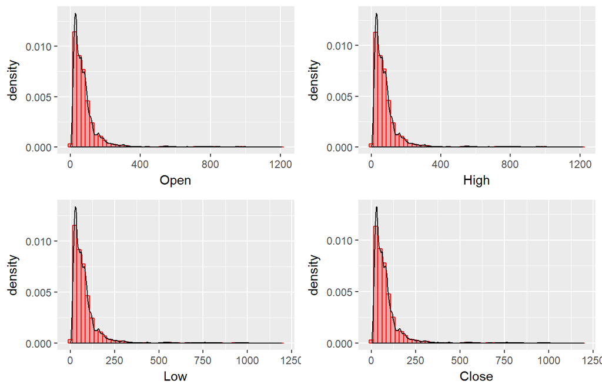

```r
options(repr.plot.width=12, repr.plot.height=12)

p1 = ggplot(s_data, aes(Open)) + geom_histogram(bins = 50, aes(y = ..density..), col = "red", fill = "red", alpha = 0.3) + geom_density()# + xlim(c(0, 1000))

p2 = ggplot(s_data, aes(High)) + geom_histogram(bins = 50, aes(y = ..density..), col = "red", fill = "red", alpha = 0.3) + geom_density()# + xlim(c(0, 1000))

p3 = ggplot(s_data, aes(Low)) + geom_histogram(bins = 50, aes(y = ..density..), col = "red", fill = "red", alpha = 0.3) + geom_density()# + xlim(c(0, 1000))

p4 = ggplot(s_data, aes(Close)) + geom_histogram(bins = 50, aes(y = ..density..), col = "red", fill = "red", alpha = 0.3) + geom_density()# + xlim(c(0, 1000))

grid.arrange(p1,p2,p3,p4, nrow=2,ncol=2)
```